# Examen Final

*177508 - Uriel Miranda Miñón*

*175904 - Jorge III Altamirano Astorga*

## 3.1 Bootstrap paramétrico.

- Escribe la función de verosimilitud y calcula el estimador de máxima verosimilitud para $\sigma^2$. Supongamos que observamos los datos x (en la carpeta datos), ¿Cuál es tu estimación de la varianza?

*sigma = 11.45823*

*Función de máxima verosimilitud*

```r
sigma_mv <-function(n,x,mu) sqrt(1 / n * sum((x-mu) ^ 2))
load("data_est_comp/x.RData")
load("data_est_comp/rabbits.RData")
n <- length(x)
mu <- 0
n
```

```
## [1] 150
```

```r
mu
```

```
## [1] 0
```

```r
sigma_mv(n, x, mu)
```

```
## [1] 11.45823
```

*Estimación de varianza*

```r
varianza <- sigma_mv(n,x,mu)
varianza
```

```
## [1] 11.45823
```

- Aproxima el error estándar de la estimación usando bootstrap paramétrico y realiza un histograma de las replicaciones bootstrap.

```r
n <- length(x)
sigma_hat <- varianza

thetaBoot <- function(){
    # Simular X_1*,...X_N* con distribución N(mu_hat, sigma_hat^2)
    x_boot <- rnorm(n, mean = mu, sd = sigma_hat)
    # Calcular sigma*
    mu_boot <- mu
    sigma_boot <- sqrt(1 / n * sum((x_boot - mu_boot) ^ 2))
    sigma_boot
}

sims_boot <- rerun(3000, thetaBoot()) %>% flatten_dbl()
ERR <- sqrt(1 / 2999 * sum((sims_boot - sigma_hat) ^ 2))
ERR
```

```
## [1] 0.6716639
```

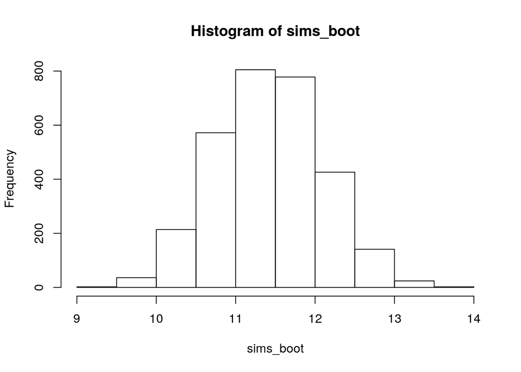

```r
hist(sims_boot)
```

## 3.2 Análisis bayesiano

- Continuamos con el problema de hacer inferencia de $\sigma^2$. Comienza especificando una inicial Gamma Inversa, justifica tu elección de los parámetros de la distribución inicial y grafica la función de densidad.

```r
x_gamma <- rgamma(2000, shape = 800, rate = 14)
x_igamma <- (1 / x_gamma) %>% as.data.frame()
x_gamma %>% summary
```

```
##    Min. 1st Qu.  Median    Mean 3rd Qu.    Max.
##   50.51   55.77   57.12   57.15   58.45   65.42
```

```r
x_igamma %>% summary
```

```
##        .
##  Min.   :0.01528
##  1st Qu.:0.01711
##  Median :0.01751
##  Mean   :0.01752
##  3rd Qu.:0.01793
##  Max.   :0.01980
```

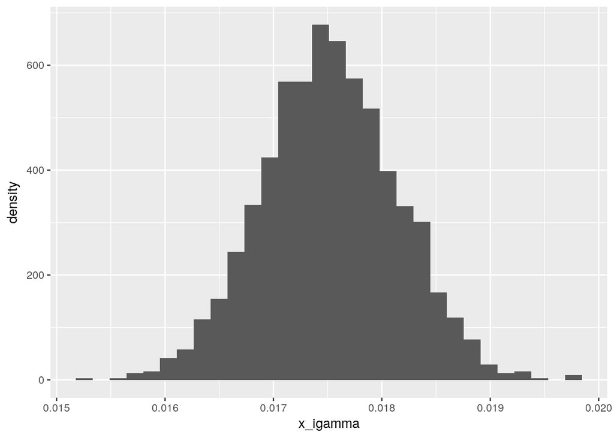

```r
ggplot(x_igamma, aes(x = x_igamma)) +
  geom_histogram(aes(y = ..density..))
```

- Calcula analíticamente la distribución posterior.

$$p(\theta|x) \propto p(x|\theta) p(\theta) =
\frac{1}{(\sigma^2)^{N/2}}
exp\bigg(-\frac{1}{2\sigma^2}\sum_{i=1}^N (x_i-\mu)^2 \bigg)
exp\bigg(-\frac{1}{2\tau^2}(\mu-m)^2)\bigg)
\frac{1}{(\sigma^2)^{\alpha +1}}
exp\bigg(-\frac{\beta}{\sigma^2}\bigg)$$

i.e.

$$\sigma^2|\mu,x \sim GI\left(\frac{N}{2} + \alpha, \sum_{i=1}^n \frac{(x_i-\mu)^2}{2} + \beta \right)$$

- Realiza un histograma de simulaciones de la distribución posterior y calcula el error estándar de la distribución.

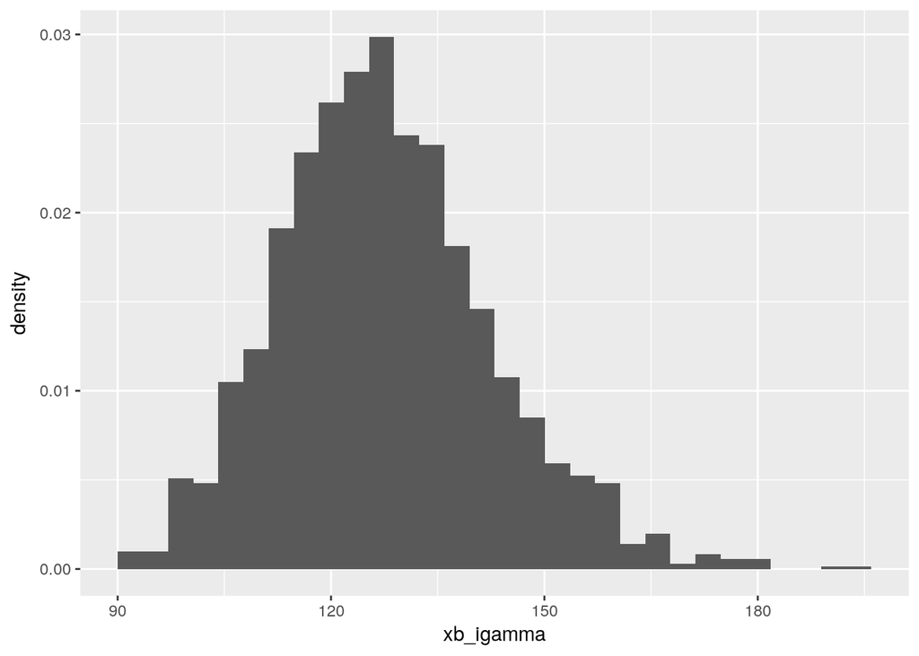

```r
xb_gamma <- rgamma(2000,shape = (n/2)+3,rate = sum(x^2)/2+3)
xb_igamma <- (1 / xb_gamma) %>% as.data.frame()

ggplot(xb_igamma, aes(x = xb_igamma)) +
  geom_histogram(aes(y = ..density..))
```

```r
ERR_2 <- sqrt(1 / 2000 * sum((xb_igamma - sigma_hat) ^ 2))
ERR_2
```

```
## [1] 117.1157
```

Ajuste con una cadena de Markov.

```r
modelo_normal.txt <-
  '
model{
  for(i in 1:N){
    x[i] ~ dnorm(0, nu)
  }
  # iniciales
  nu ~ dunif(.1, 300)
  sigma2 <- 1 / nu
  mu <-0
}
'
cat(modelo_normal.txt, file = 'modelo_normal.bugs')
# Ajustamos el Modelo (Generamos una Cadena de Markov)
jags_fit <- jags(
  model.file = "modelo_normal.bugs",    # modelo de JAGS
 # inits = jags.inits,valores iniciales
  data = list(x = x, N = n),    # lista con los datos
  parameters.to.save = c("mu", "nu", "sigma2"),  # parámetros por guardar
  n.chains = 1,   # número de cadenas
  n.iter = 10000,    # número de pasos
  n.burnin = 1000,   # calentamiento de la cadena
  n.thin = 1
)
```

```
## module glm loaded
```

```r
jags_fit
```

```
## Inference for Bugs model at "modelo_normal.bugs", fit using jags,
##  1 chains, each with 10000 iterations (first 1000 discarded)
##  n.sims = 9000 iterations saved
##           mu.vect sd.vect     2.5%      25%      50%      75%    97.5%
## mu          0.000   0.000    0.000    0.000    0.000    0.000    0.000
## nu          0.100   0.000    0.100    0.100    0.100    0.100    0.100
## sigma2      9.989   0.011    9.960    9.985    9.992    9.997   10.000
## deviance 2592.413   1.958 2590.475 2591.009 2591.836 2593.176 2597.811
##
## DIC info (using the rule, pD = var(deviance)/2)
## pD = 1.9 and DIC = 2594.3
## DIC is an estimate of expected predictive error (lower deviance is better).
```

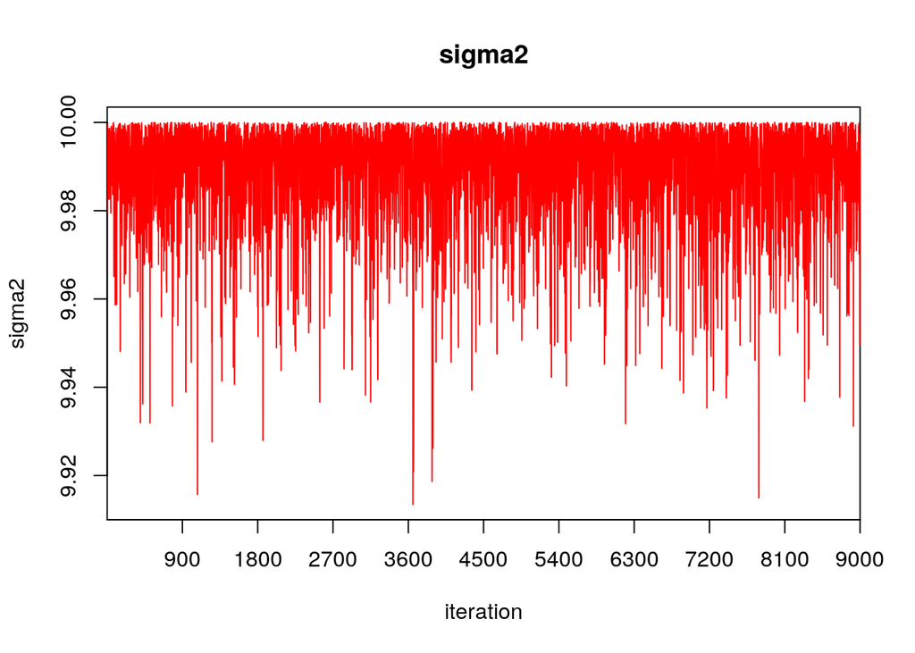

```r
traceplot(jags_fit, varname = c("sigma2"), ask = F)
```

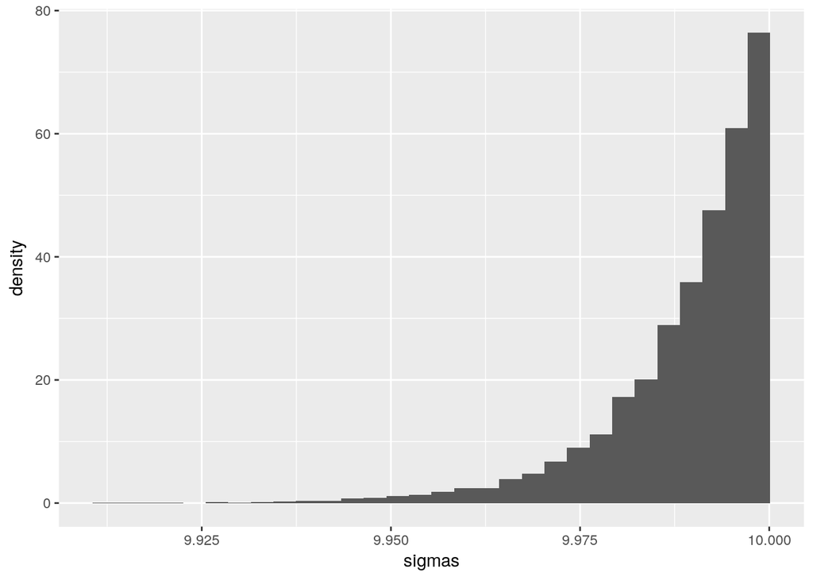

```r
sigmas <- jags_fit$BUGSoutput$sims.matrix[, 4] %>% data.frame
ggplot(sigmas, aes(x = sigmas)) +
  geom_histogram(aes(y = ..density..))
```

```r
ERR_3 <- sqrt(1 / 2000 * sum((sigmas - sigma_hat) ^ 2))
ERR_3
```

```
## [1] 3.116474
```

## 3.3 Supongamos que ahora buscamos hacer inferencia del parámetro $\tau=log(\sigma)$, ¿cuál es el estimador de máxima verosimilitud?

```r
T <- log(sigma_hat)
T
```

```
## [1] 2.438708
```

- Utiliza bootstrap paramétrico para generar un intervalo de confianza del 95% para el parámetro $\tau$ y realiza un histograma de las replicaciones bootstrap.

```r
mu <-0
sigma_hat <- sqrt(1 / n * sum((x - mu) ^ 2))
mu
```

```
## [1] 0
```

```r
sigma_hat
```

```
## [1] 11.45823
```

```r
thetaBoot_log <- function(){
    # Simular X_1*,...X_N* con distribución N(mu_hat, sigma_hat^2)
    x_boot <- rnorm(n, mean = mu, sd = sigma_hat)
    # Calcular sigma*
    mu_boot <- mean(x_boot)
    sigma_boot <- sqrt(1 / n * sum((x_boot - mu_boot) ^ 2))
    log(sigma_boot)
}

sims_boot_log <- rerun(3000, thetaBoot_log()) %>% flatten_dbl()
log_inf <- quantile(sims_boot_log, 0.025)
log_sup <- quantile(sims_boot_log, 0.975)
log_inf
```

```
##     2.5%
## 2.316801
```

```r
log_sup
```

```
##    97.5%
## 2.539103
```

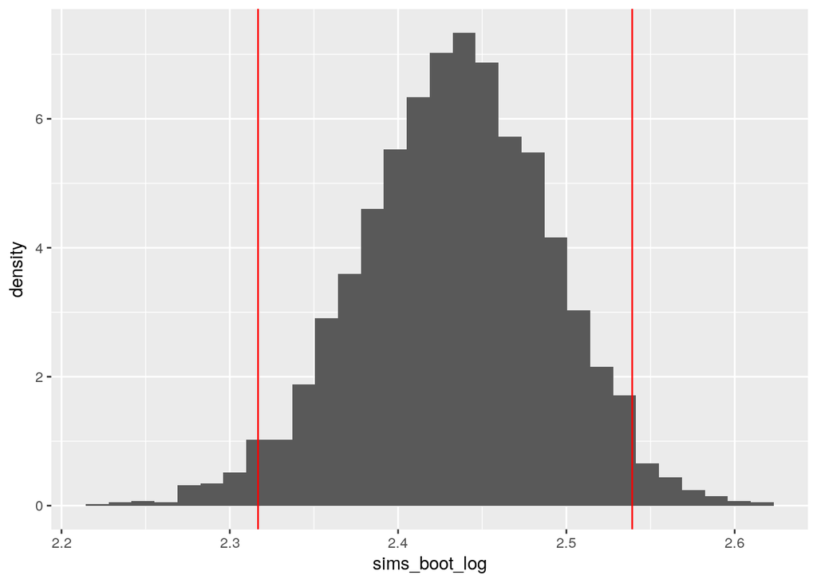

```r
sims_boot_log <- sims_boot_log %>% data.frame
ggplot(sims_boot_log, aes(x = sims_boot_log)) +
  geom_histogram(aes(y = ..density..)) +
  geom_vline(xintercept = log_inf, color = "red") +
  geom_vline(xintercept = log_sup, color = "red")
```

- Ahora volvamos a inferencia bayesiana, calcula un intervalo de confianza para $\tau$ y un histograma de la distribución posterior de $\tau$ utilizando la inicial uniforme (para $\sigma^2$).

```r
modelo_teta.txt <-
  '
model{
  for(i in 1:N){
    x[i] ~ dnorm(0, nu)
  }
  # iniciales
  nu ~ dunif(.1, 300)
  sigma2 <- 1 / nu
  mu <-0
  teta <- log(sigma2)
}
'
cat(modelo_teta.txt, file = 'modelo_normal_log.bugs')

# Ajustamos el Modelo (Generamos una Cadena de Markov)
jags_fit_teta <- jags(
  model.file = "modelo_normal_log.bugs",    # modelo de JAGS
 # inits = jags.inits,   # valores iniciales
  data = list(x = x, N = n),    # lista con los datos
  parameters.to.save = c("mu", "nu", "teta"),  # parámetros por guardar
  n.chains = 1,   # número de cadenas
  n.iter = 10000,    # número de pasos
  n.burnin = 1000,   # calentamiento de la cadena
  n.thin = 1
)
jags_fit_teta
```

```
## Inference for Bugs model at "modelo_normal_log.bugs", fit using jags,
##  1 chains, each with 10000 iterations (first 1000 discarded)
##  n.sims = 9000 iterations saved
##           mu.vect sd.vect     2.5%      25%      50%      75%    97.5%
## mu          0.000   0.000    0.000    0.000    0.000    0.000    0.000
## nu          0.100   0.000    0.100    0.100    0.100    0.100    0.100
## teta        2.301   0.001    2.299    2.301    2.302    2.302    2.303
## deviance 2592.478   1.995 2590.480 2591.030 2591.876 2593.291 2597.846
##
## DIC info (using the rule, pD = var(deviance)/2)
## pD = 2.0 and DIC = 2594.5
## DIC is an estimate of expected predictive error (lower deviance is better).
```

```r
teta_mc <- jags_fit_teta$BUGSoutput$sims.matrix[,4]
teta_inf <- quantile(teta_mc, 0.025)
teta_sup <- quantile(teta_mc, 0.975)
teta_inf
```

```
##    2.5%
## 2.29852
```

```r
teta_sup
```

```
##   97.5%
## 2.30256
```

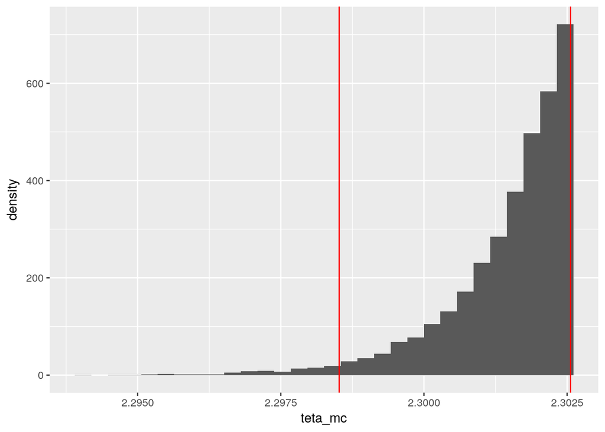

```r
teta_mc <- teta_mc %>% data.frame
ggplot(teta_mc, aes(x = teta_mc)) +
  geom_histogram(aes(y = ..density..)) +
  geom_vline(xintercept = teta_inf, color = "red") +
  geom_vline(xintercept = teta_sup, color = "red")
```

## 4. Metrópolis

En la tarea de Análisis Bayesiano (respuestas aquí programaste un algoritmo de Metropolis para el caso Normal con varianza conocida. En el ejercicio de la tarea los saltos se proponían de acuerdo a una distribución normal: N(0, 5). Para este ejercicio modifica el código con el fin de calcular el porcentaje de valores rechazados y considera las siguientes distribuciones propuesta: a) N(0,0.2), b) N(0,5) y c) N(0,20).

- 4.1 Genera valores de la distribución posterior usando cada una de las distribuciones propuesta, utiliza la misma distribución inicial y datos observados que utilizaste en la tarea (realiza 6000 pasos). Grafica los primeros 2000 pasos de la cadena. Comenta acerca de las similitudes/diferencias entre las gráficas.

*Claramente entre el segundo parámetro de N sea más grande, en el código `sd_prop` hay más distancia (varianza) entre los pasos. Por lo que se ven mucho más espaciados entre paso y paso. 0.2 se ve casí como una “mancha”, mientra 5 y 20 se ven distanciados.*

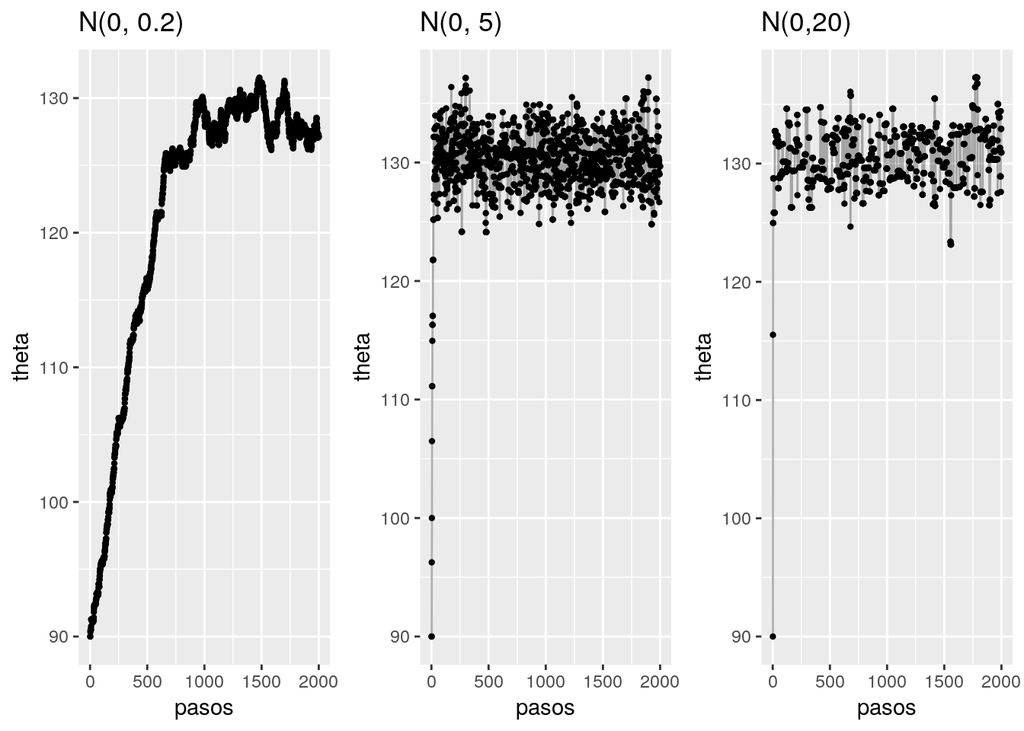

```r
prior <- function(mu = 100, tau = 10){
  mu <- mu
  tau <- tau
  function(theta){
    dnorm(theta, mu, tau)
  }
}
mu <- 150
tau <- 15
mi_prior <- prior(mu, tau)
# mu
# tau
# mi_prior(5)
# S: sum x_i, S2: sum x_i^2, N: número obs., sigma: desviación estándar (conocida)
S <- 13000
S2 <- 1700000
N <- 100
sigma <- 20
likeNorm <- function(S, S2, N, sigma = sigma){
  # quitamos constantes
  sigma2 <-  sigma ^ 2
  function(theta){
    exp(-1 / (2 * sigma2) * (S2 - 2 * theta * S +
        N * theta ^ 2))
  }
}
mi_like <- likeNorm(S = S, S2 = S2, N = N, sigma = sigma)
# mi_like(130)
postRelProb <- function(theta){
  mi_like(theta) * mi_prior(theta)
}
caminaAleat <- function(theta, sd_prop = .2){ # theta: valor actual
  salto_prop <- rnorm(n = 1, sd = sd_prop) # salto propuesto
  theta_prop <- theta + salto_prop # theta propuesta
  u <- runif(1)
  p_move = min(postRelProb(theta_prop) / postRelProb(theta), 1) # prob mover
  if(p_move  > u){
    return(theta_prop) # aceptar valor propuesto
  }
  else{
    return(theta) # rechazar
  }
}

### 0.2
# Generamos la caminata aleatoria
pasos <- 6000
camino <- numeric(pasos) # vector que guardará las simulaciones
camino[1] <- 90 # valor inicial
rechazo = 0

for (j in 2:pasos){
  camino[j] <- caminaAleat(camino[j - 1])
  rechazo <- rechazo + 1 * (camino[j] == camino[j - 1])
}

rp0.2 <- rechazo / pasos
caminata0.2 <- data.frame(pasos = 1:pasos, theta = camino)
g1 <- ggplot(caminata0.2[1:2000, ], aes(x = pasos, y = theta)) +
  geom_point(size = 0.8) +
  geom_path(alpha = 0.3) +
  ggtitle("N(0, 0.2)")

#### 5
# Generamos la caminata aleatoria
pasos <- 6000
camino <- numeric(pasos) # vector que guardará las simulaciones
camino[1] <- 90 # valor inicial
rechazo = 0

for (j in 2:pasos){
  camino[j] <- caminaAleat(camino[j - 1], sd_prop = 5)
  rechazo <- rechazo + 1 * (camino[j] == camino[j - 1])
}

rp5 <- rechazo / pasos
caminata5 <- data.frame(pasos = 1:pasos, theta = camino)
g2 <- ggplot(caminata5[1:2000, ], aes(x = pasos, y = theta)) +
  geom_point(size = 0.8) +
  geom_path(alpha = 0.3) +
  ggtitle("N(0, 5)")

#### 20
# Generamos la caminata aleatoria
pasos <- 6000
camino <- numeric(pasos) # vector que guardará las simulaciones
camino[1] <- 90 # valor inicial
rechazo = 0

for (j in 2:pasos){
  camino[j] <- caminaAleat(camino[j - 1], sd_prop = 20)
  rechazo <- rechazo + 1 * (camino[j] == camino[j - 1])
}

rp20 <- rechazo / pasos
caminata20 <- data.frame(pasos = 1:pasos, theta = camino)
g3 <- ggplot(caminata20[1:2000, ], aes(x = pasos, y = theta)) +
  geom_point(size = 0.8) +
  geom_path(alpha = 0.3) +
  ggtitle("N(0,20)")
grid.arrange(g1,g2,g3,ncol=3)
```

- 4.2 Calcula el porcentaje de valores rechazados, compara los resultados y explica a que se deben las diferencias.

*A las mencionadas “varianzas” entre pasos.*

```r
rechazo <- data.frame(sd = c(0.2,5,20), rechazo_paso =c(rp0.2,rp5,rp20))
rechazo
```

| sd | rechazo_paso |
| --- | --- |
| 0.2 | 0.0640000 |
| 5.0 | 0.5731667 |
| 20.0 | 0.8703333 |

- 4.3 Elimina las primeras 1000 simulaciones y genera histogramas de la distribución posterior para cada caso, ¿que distribución propuesta nos da la representación más cercana a la verdadera distribución posterior? (compara las simulaciones de los tres escenarios de distribución propuesta con la distribución posterior calculada de manera analítica)

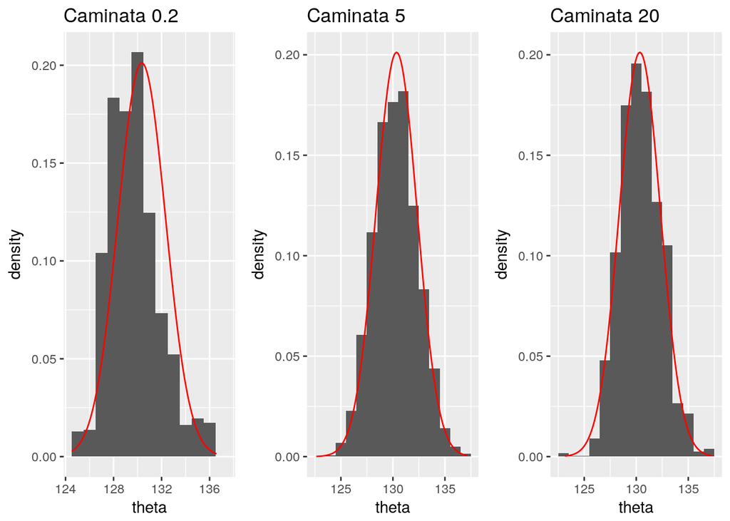

```r
caminata0.2 <- filter(caminata0.2, pasos > 1000)
caminata5 <- filter(caminata5, pasos > 1000)
caminata20 <- filter(caminata20, pasos > 1000)
media_calc <- 20 ^ 2 * 150 / (20 ^ 2 + 100 * 15 ^ 2) + 15 ^ 2 * 13000 / (20^2  + 100 * 15^2)
sd_calc <- sigma ^ 2 * tau ^ 2 / (sigma ^ 2 + N * tau ^ 2)
sd_calc<- sqrt(sd_calc)
g1 <- ggplot(caminata0.2, aes(x = theta)) +
  geom_histogram(aes(y = ..density..), binwidth = 1)+
  stat_function(fun = dnorm, args = list(mean = media_calc, sd = sd_calc), color = "red") +
  ggtitle("Caminata 0.2")
g2 <- ggplot(caminata5, aes(x = theta)) +
  geom_histogram(aes(y = ..density..), binwidth = 1)+
  stat_function(fun = dnorm, args = list(mean = media_calc, sd = sd_calc), color = "red") +
  ggtitle("Caminata 5")
g3 <- ggplot(caminata20, aes(x = theta)) +
  geom_histogram(aes(y = ..density..), binwidth = 1)+
  stat_function(fun = dnorm, args = list(mean = media_calc, sd = sd_calc), color = "red") +
  ggtitle("Caminata 20")
grid.arrange(g1,g2,g3, ncol=3)
```

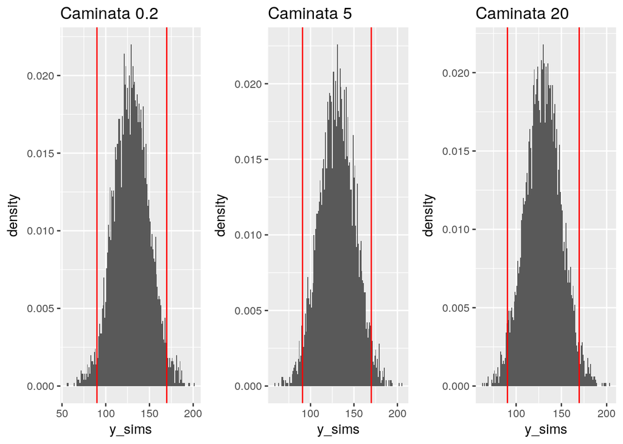

```r
caminata0.2f<- data.frame(pasos = 1:nrow(caminata0.2), mu = caminata0.2[1:nrow(caminata0.2), 2],
  sigma = sigma)
caminata0.2f$y_sims <- rnorm(1:nrow(caminata0.2f), caminata0.2f$mu, caminata0.2f$sigma)

teta_inf0.2 <- quantile(caminata0.2f$y_sims, 0.025, na.rm = TRUE)
teta_sup0.2 <- quantile(caminata0.2f$y_sims, 0.975, na.rm = TRUE)

g1 <- ggplot(caminata0.2f, aes(x = y_sims)) +
  geom_histogram(aes(y = ..density..), binwidth = 1) +
  geom_vline(xintercept = teta_inf0.2, color = "red") +
  geom_vline(xintercept = teta_sup0.2, color = "red") +
  ggtitle("Caminata 0.2")
caminata5f<- data.frame(pasos = 1:nrow(caminata5), mu = caminata5[1:nrow(caminata5), 2],
  sigma = sigma)

caminata5f$y_sims <- rnorm(1:nrow(caminata5f), caminata5f$mu, caminata5f$sigma)

teta_inf5 <- quantile(caminata5f$y_sims, 0.025, na.rm = TRUE)
teta_sup5 <- quantile(caminata5f$y_sims, 0.975, na.rm = TRUE)

g2 <- ggplot(caminata5f, aes(x = y_sims)) +
  geom_histogram(aes(y = ..density..), binwidth = 1) +
  geom_vline(xintercept = teta_inf5, color = "red") +
  geom_vline(xintercept = teta_sup5, color = "red") +
  ggtitle("Caminata 5")
caminata20f<- data.frame(pasos = 1:nrow(caminata20), mu = caminata20[1:nrow(caminata20), 2],
  sigma = sigma)

caminata20f$y_sims <- rnorm(1:nrow(caminata20f), caminata20f$mu, caminata20f$sigma)

teta_inf20 <- quantile(caminata20f$y_sims, 0.025, na.rm = TRUE)
teta_sup20 <- quantile(caminata20f$y_sims, 0.975, na.rm = TRUE)

g3 <- ggplot(caminata20f, aes(x = y_sims)) +
  geom_histogram(aes(y = ..density..), binwidth = 1)+
  geom_vline(xintercept = teta_inf20, color = "red") +
  geom_vline(xintercept = teta_sup20, color = "red") +
  ggtitle("Caminata 20")
grid.arrange(g1,g2,g3,ncol=3)
```

```r
rm(g1,g2,g3)

data.frame(N=c(0.2,5,20),
           inf=c(teta_inf0.2, teta_inf5, teta_inf20),
           sup=c(teta_sup0.2, teta_sup5, teta_sup20))
```

| N | inf | sup |
| --- | --- | --- |
| 0.2 | 89.94603 | 169.7546 |
| 5.0 | 90.81369 | 169.9575 |
| 20.0 | 90.45294 | 169.6712 |

### 5. Modelos jerárquicos

- 5.1 Si piensas en este problema como un lanzamiento de monedas, ¿a qué corresponden las monedas y los lanzamientos?
- 5.2 La base de datos rabbits contiene las observaciones de los 71 experimentos, cada renglón corresponde a una observación.

```r
rabbits
```

| tumor | experiment |
| --- | --- |
| 1 | 1 |
| 0 | 1 |
| 0 | 1 |
| 0 | 1 |
| 0 | 1 |
| 0 | 1 |
| 0 | 1 |
| 0 | 1 |
| 0 | 1 |
| 0 | 1 |

[output cut: 1800 more lines]

```r
summary(rabbits)
```

```
##      tumor          experiment
##  Min.   :0.0000   Min.   : 1.00
##  1st Qu.:0.0000   1st Qu.:23.00
##  Median :0.0000   Median :39.00
##  Mean   :0.1867   Mean   :38.76
##  3rd Qu.:0.0000   3rd Qu.:57.00
##  Max.   :1.0000   Max.   :71.00
```

```r
summary(rabbits$tumor %>% as.factor())
```

```
##    0    1
## 1472  338
```

- Utiliza JAGS ~o Stan~ para ajustar un modelo jerárquico como el descrito arriba y usando una inicial $Beta(1,1)$ y una $Gamma(1,0.1)$ para $\mu$ y $\kappa$ respectivamente.

```r
modelo_conejos.txt <-
'
model{
  for(i in 1 : N) {
    y[i] ~ dbern(p[expr[i]])
  }
  for(j in 1 : nExp) {
    p[j] ~ dbeta(a, b)
  }
  a <- mu*k
  b <- (1-mu)*k
  mu ~ dbeta(1, 1)
  k ~ dgamma(1, 0.1)
}
'
cat(modelo_conejos.txt, file = 'modelo_conejos.txt')
jags_fit_conejos <- jags(
  model.file = "modelo_conejos.txt",    # modelo de JAGS
# inits = jags.inits,   # valores iniciales
  data = list(y = rabbits$tumor, expr = rabbits$experiment,
              nExp = length(unique(rabbits$experiment)),
              N = length(rabbits$tumor)),    # lista con los datos
  parameters.to.save = c("mu", "k", "p"),  # parámetros por guardar
  n.chains = 3,   # número de cadenas
  n.iter = 6000,    # número de pasos
  n.burnin = 1000   # calentamiento de la cadena
  )
#jags_fit_conejos
```

- Realiza un histograma de la distribución posterior de $\mu$, $\kappa$. Comenta tus resultados.

[figure not shown]

```r
k_pasos <- jags_fit_conejos$BUGSoutput$sims.matrix[,2]
k_pasos <- data.frame(k = k_pasos)
mu_pasos <- jags_fit_conejos$BUGSoutput$sims.matrix[,3]
mu_pasos <- data.frame(mu = mu_pasos)

g1 <- ggplot(k_pasos, aes(x = k)) +
  geom_histogram(aes(y = ..density..)) +
  ggtitle("Posterior de mu")
g2 <- ggplot(mu_pasos, aes(x = mu)) +
  geom_histogram(aes(y = ..density..)) +
  ggtitle("Posterior de kappa")
grid.arrange(g1,g2,ncol=2)
```

- 5.3 Realiza una gráfica de boxplots con las simulaciones de cada parámetro θj, la gráfica será similar a la realizda en la clase de modelos probabilísticos (clase 9). Comenta tus resultados

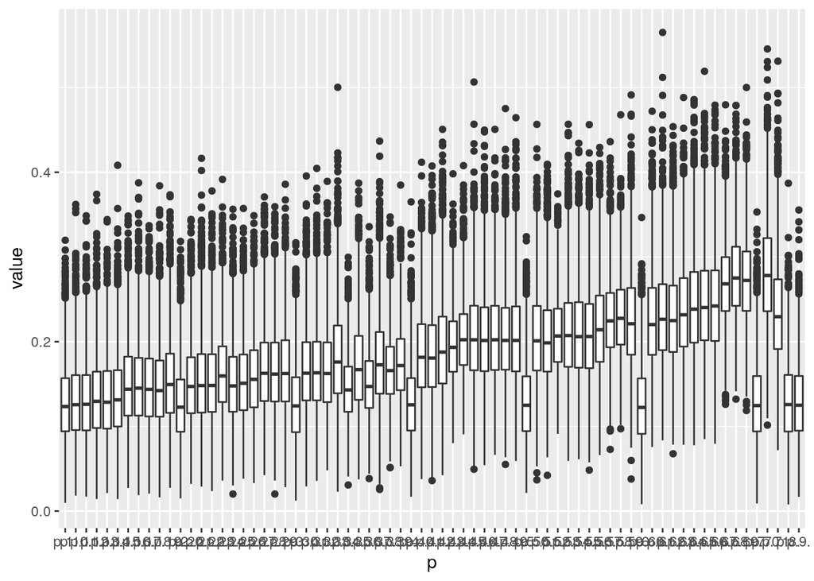

```r
p <- jags_fit_conejos$BUGSoutput$sims.matrix[,-c(1:3)] %>% data.frame
med_p_52 <- colMeans(p)
q <- gather(p,key = p)
ggplot(q, aes(p, value)) + geom_boxplot()
```

```r
modelo_conejos54.txt <-
'
model{
  for(i in 1 : N) {
    y[i] ~ dbern(p[expr[i]])
  }
  for(j in 1 : nExp) {
    p[j] ~ dbeta(a, b)
  }
  a <- mu*k
  b <- (1-mu)*k
  mu ~ dbeta(10, 10)
  k ~ dgamma(.51, 00.1)
}
'
cat(modelo_conejos54.txt, file = 'modelo_conejos54.txt')
jags_fit_conejos54 <- jags(
  model.file = "modelo_conejos54.txt",    # modelo de JAGS
# inits = jags.inits,   # valores iniciales
  data = list(y = rabbits$tumor, expr = rabbits$experiment,
              nExp = length(unique(rabbits$experiment)),
              N = length(rabbits$tumor)),    # lista con los datos
  parameters.to.save = c("mu", "k", "p"),  # parámetros por guardar
  n.chains = 3,   # número de cadenas
  n.iter = 6000,    # número de pasos
  n.burnin = 1000   # calentamiento de la cadena
  )
# jags_fit_conejos54
```

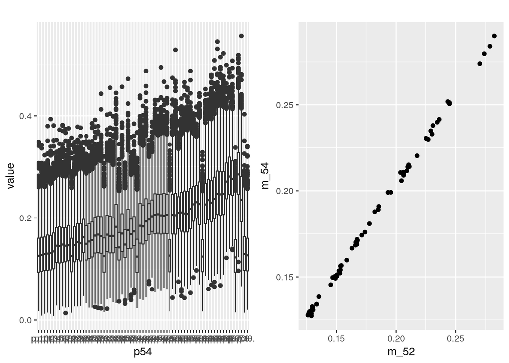

```r
p54 <- jags_fit_conejos54$BUGSoutput$sims.matrix[,-c(1:3)] %>% data.frame
med_p_54 <- colMeans(p54)
q54 <- gather(p54,key = p54)
g1 <- ggplot(q54, aes(p54, value)) +
  geom_boxplot() +
  ggtitle("")
media_5254 <- data.frame(m_52 = med_p_52, m_54 = med_p_54)
g2 <- ggplot(media_5254, aes(x = m_52, y = m_54)) +
  geom_point() +
  ggtitle("")
grid.arrange(g1,g2,ncol=2)
```